# Lab 5 Solutions

Tom Keefe

October 11, 2018

# Instructions

**Exercises:** 1,3 (Pg. 227); 2 (Pg. 232); 1,2 (Pg. 235);

**Assigned:** Friday, October 12, 2018

**Due:** Friday, October 19, 2018 by 5:00 PM

**Submission:** Submit via an electronic document on Sakai. Must be submitted as a HTML file generated in RStudio. All assigned problems are chosen according to the textbook *R for Data Science*. You do not need R code to answer every question. If you answer without using R code, delete the code chunk. If the question requires R code, make sure you display R code. If the question requires a figure, make sure you display a figure. A lot of the questions can be answered in written response, but require R code and/or figures for understanding and explaining.

# Chapter 12 (Pg. 227)

## Exercise 1

The default bar chart is hard to read because the labels on the x-axis are squished together. We can fix this by flipping the coordinates, as described in the diamonds chapter.

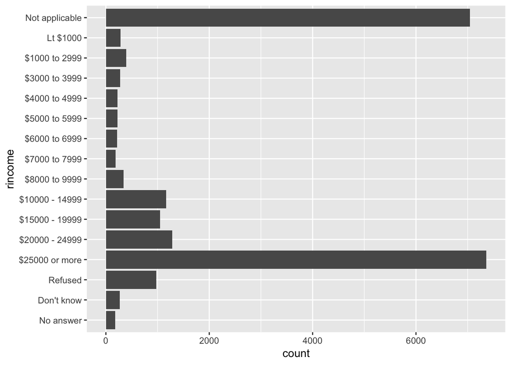

```r
ggplot(gss_cat, aes(rincome)) + geom_bar() + coord_flip()
```

## Exercise 3

In this dataset, `denom` only applies to Protestants. To get this information in a table, use a group_by.

```r
gss_cat %>% group_by(relig) %>% summarise(denoms=n_distinct(denom)) %>% arrange(-denoms)
```

```
## # A tibble: 15 x 2
##    relig                   denoms
##    <fct>                    <int>
##  1 Protestant                  29
##  2 Christian                    4
##  3 Other                        2
##  4 No answer                    1
##  5 Don't know                   1
##  6 Inter-nondenominational      1
##  7 Native american              1
##  8 Orthodox-christian           1
##  9 Moslem/islam                 1
## 10 Other eastern                1
## 11 Hinduism                     1
## 12 Buddhism                     1
## 13 None                         1
## 14 Jewish                       1
## 15 Catholic                     1
```

We see that `Protestant`, `Christian`, and `Other` have denominations.

One way to see this visually is a heatmap

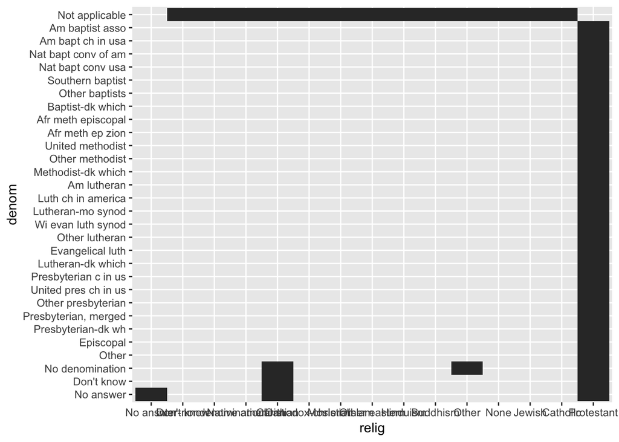

```r
ggplot(gss_cat, aes(x=relig, y=denom)) + geom_tile()
```

# Chapter 12 (Pg. 232)

## Exercise 2

```r
str(gss_cat)
```

```
## Classes 'tbl_df', 'tbl' and 'data.frame':    21483 obs. of  9 variables:
##  $ year   : int  2000 2000 2000 2000 2000 2000 2000 2000 2000 2000 ...
##  $ marital: Factor w/ 6 levels "No answer","Never married",..: 2 4 5 2 4 6 2 4 6 6 ...
##  $ age    : int  26 48 67 39 25 25 36 44 44 47 ...
##  $ race   : Factor w/ 4 levels "Other","Black",..: 3 3 3 3 3 3 3 3 3 3 ...
##  $ rincome: Factor w/ 16 levels "No answer","Don't know",..: 8 8 16 16 16 5 4 9 4 4 ...
##  $ partyid: Factor w/ 10 levels "No answer","Don't know",..: 6 5 7 6 9 10 5 8 9 4 ...
##  $ relig  : Factor w/ 16 levels "No answer","Don't know",..: 15 15 15 6 12 15 5 15 15 15 ...
##  $ denom  : Factor w/ 30 levels "No answer","Don't know",..: 25 23 3 30 30 25 30 15 4 25 ...
##  $ tvhours: int  12 NA 2 4 1 NA 3 NA 0 3 ...
```

```r
levels(gss_cat$marital)
```

```
## [1] "No answer"     "Never married" "Separated"     "Divorced"
## [5] "Widowed"       "Married"
```

```r
levels(gss_cat$race)
```

```
## [1] "Other"          "Black"          "White"          "Not applicable"
```

```r
levels(gss_cat$rincome)
```

```
##  [1] "No answer"      "Don't know"     "Refused"        "$25000 or more"
##  [5] "$20000 - 24999" "$15000 - 19999" "$10000 - 14999" "$8000 to 9999"
##  [9] "$7000 to 7999"  "$6000 to 6999"  "$5000 to 5999"  "$4000 to 4999"
## [13] "$3000 to 3999"  "$1000 to 2999"  "Lt $1000"       "Not applicable"
```

```r
levels(gss_cat$partyid)
```

```
##  [1] "No answer"          "Don't know"         "Other party"
##  [4] "Strong republican"  "Not str republican" "Ind,near rep"
##  [7] "Independent"        "Ind,near dem"       "Not str democrat"
## [10] "Strong democrat"
```

```r
levels(gss_cat$relig)
```

```
##  [1] "No answer"               "Don't know"
##  [3] "Inter-nondenominational" "Native american"
##  [5] "Christian"               "Orthodox-christian"
##  [7] "Moslem/islam"            "Other eastern"
##  [9] "Hinduism"                "Buddhism"
## [11] "Other"                   "None"
## [13] "Jewish"                  "Catholic"
## [15] "Protestant"              "Not applicable"
```

```r
levels(gss_cat$denom)
```

```
##  [1] "No answer"            "Don't know"           "No denomination"
##  [4] "Other"                "Episcopal"            "Presbyterian-dk wh"
##  [7] "Presbyterian, merged" "Other presbyterian"   "United pres ch in us"
## [10] "Presbyterian c in us" "Lutheran-dk which"    "Evangelical luth"
## [13] "Other lutheran"       "Wi evan luth synod"   "Lutheran-mo synod"
## [16] "Luth ch in america"   "Am lutheran"          "Methodist-dk which"
## [19] "Other methodist"      "United methodist"     "Afr meth ep zion"
## [22] "Afr meth episcopal"   "Baptist-dk which"     "Other baptists"
## [25] "Southern baptist"     "Nat bapt conv usa"    "Nat bapt conv of am"
## [28] "Am bapt ch in usa"    "Am baptist asso"      "Not applicable"
```

`rincome` and `partyid` have principled orders, the others are arbitrary.

# Chapter 12 (Pg. 235)

## Exercise 1

I’ll use a plot to show how the proportions have changed over time.

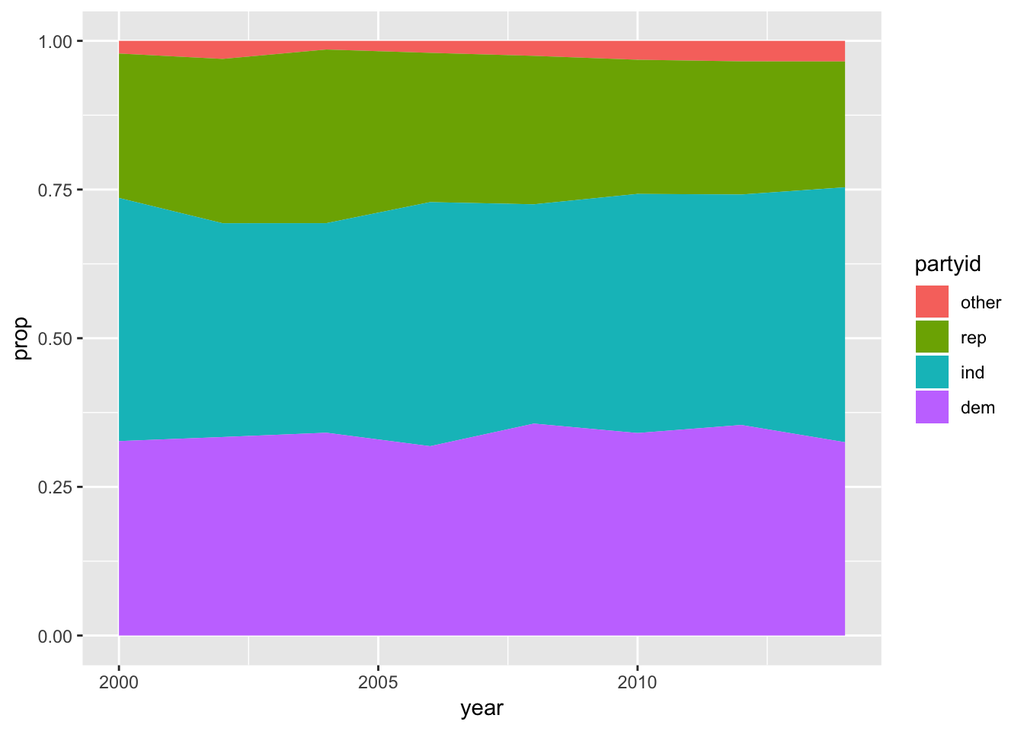

```r
gss_cat %>% mutate(partyid = fct_collapse(partyid,
                                         other = c("No answer", "Don't know", "Other party"),
                                        rep = c("Strong republican", "Not str republican"),
                                        ind = c("Ind,near rep", "Independent", "Ind,near dem"),
                                        dem = c("Not str democrat", "Strong democrat")
                                        )
                   ) %>%
    group_by(year, partyid) %>%
    count() %>%
    group_by(year) %>%
    mutate(prop=n/sum(n)) %>%
    ggplot(aes(x=year, y=prop, fill=partyid)) + geom_area()
```

The proportions have been more or less stable since 2000. The number of Republicans has shrank slightly, with some of that loss being taken up by independents.

## Exercise 2

We can use `fct_lump` to collapse `rincome` into a smaller set of categories (e.g. 5 categories.)

```r
gss_cat %>% mutate(rincome=fct_lump(rincome, n=5)) %>% count(rincome)
```

```
## # A tibble: 6 x 2
##   rincome            n
##   <fct>          <int>
## 1 $25000 or more  7363
## 2 $20000 - 24999  1283
## 3 $15000 - 19999  1048
## 4 $10000 - 14999  1168
## 5 Not applicable  7043
## 6 Other           3578
```